```python
import geopandas as gp
import numpy as np
import os
import pandas as pd
import matplotlib as mtplt
import seaborn as sb
import matplotlib.pyplot as plt
from matplotlib.dates import DateFormatter
from matplotlib.ticker import FuncFormatter
import matplotlib.dates as mdates
```

```python
import re

def eliminar_tildes(texto):
        texto = re.sub('á','a', texto)
        texto = re.sub('é','e', texto)
        texto = re.sub('í','i', texto)
        texto = re.sub('ó','o', texto)
        texto = re.sub('ú','u', texto)
        texto = re.sub('ñ','n', texto)
        return texto.upper()

def arreglar(texto):
    texto = texto.lower()
    texto = eliminar_tildes(texto)
    texto = texto.title()
    return texto
```

Tarea 1

# 1. [50 puntos] Utilizando los datos del archivo `02_17_21_EXCEL_SERIES.xlsx` realice lo siguiente:

## a) Utilizando la función `read_excel` de la bibliotega pandas lea los datos.

```python
datos = pd.read_excel('../datos/02_17_21_EXCEL_SERIES.xlsx',sheet_name= "3_4 DIST_ACTIV")


datos= pd.melt(datos,
id_vars = ['cod_provin',"provincia",'cod_canton',"canton",'codigo_dta','distrito'],
var_name = 'fecha',
value_name = 'activos')
datos['fecha'] = pd.to_datetime(datos['fecha'], format = "%Y-%m-%d")
datos.tail(10)
```

|  | cod_provin | provincia | cod_canton | canton | codigo_dta | distrito | fecha | activos |
| --- | --- | --- | --- | --- | --- | --- | --- | --- |
| 136220 | 7 | Limón | 703 | Siquirres | 70302 | Pacuarito | 2021-02-17 | 41 |
| 136221 | 7 | Limón | 703 | Siquirres | 70307 | Reventazón | 2021-02-17 | 0 |
| 136222 | 7 | Limón | 703 | Siquirres | 70301 | Siquirres | 2021-02-17 | 173 |
| 136223 | 7 | Limón | 703 | Siquirres | 70399 | Sin información de distrito | 2021-02-17 | 0 |
| 136224 | 7 | Limón | 704 | Talamanca | 70401 | Bratsi | 2021-02-17 | 11 |
| 136225 | 7 | Limón | 704 | Talamanca | 70403 | Cahuita | 2021-02-17 | 34 |
| 136226 | 7 | Limón | 704 | Talamanca | 70402 | Sixaola | 2021-02-17 | 18 |
| 136227 | 7 | Limón | 704 | Talamanca | 70404 | Telire | 2021-02-17 | 1 |
| 136228 | 7 | Limón | 704 | Talamanca | 70499 | Sin información de distrito | 2021-02-17 | 0 |
| 136229 | 9 | Otros | 999 | Otros | 99999 | Otros | 2021-02-17 | 54 |

## b) Seleccione una provincia de su preferencia y filtre la tabla para que sólo contenga los casos activos de esa provincia.

```python
datos_SJ = datos[datos["provincia"] == "San José"]
datos_SJ.tail()
```

|  | cod_provin | provincia | cod_canton | canton | codigo_dta | distrito | fecha | activos |
| --- | --- | --- | --- | --- | --- | --- | --- | --- |
| 135798 | 1 | San José | 111 | Vazquez de Coronado | 11103 | Dulce Nombre de Jesús | 2021-02-17 | 53 |
| 135799 | 1 | San José | 111 | Vazquez de Coronado | 11104 | Patalillo | 2021-02-17 | 88 |
| 135800 | 1 | San José | 111 | Vazquez de Coronado | 11101 | San Isidro | 2021-02-17 | 101 |
| 135801 | 1 | San José | 111 | Vazquez de Coronado | 11102 | San Rafael | 2021-02-17 | 41 |
| 135802 | 1 | San José | 111 | Vázquez de Coronado | 11199 | Sin información de distrito | 2021-02-17 | 1 |

```python
datos = datos[datos["fecha"] == "2021-02-17"]
datos.head(10)
```

|  | cod_provin | provincia | cod_canton | canton | codigo_dta | distrito | fecha | activos |
| --- | --- | --- | --- | --- | --- | --- | --- | --- |
| 135660 | 1 | San José | 112 | Acosta | 11204 | Cangrejal | 2021-02-17 | 4 |
| 135661 | 1 | San José | 112 | Acosta | 11202 | Guaitil | 2021-02-17 | 4 |
| 135662 | 1 | San José | 112 | Acosta | 11203 | Palmichal | 2021-02-17 | 9 |
| 135663 | 1 | San José | 112 | Acosta | 11205 | Sabanillas | 2021-02-17 | 4 |
| 135664 | 1 | San José | 112 | Acosta | 11201 | San Ignacio | 2021-02-17 | 20 |
| 135665 | 1 | San José | 112 | Acosta | 11299 | Sin información de distrito | 2021-02-17 | 0 |
| 135666 | 1 | San José | 110 | Alajuelita | 11001 | Alajuelita | 2021-02-17 | 141 |
| 135667 | 1 | San José | 110 | Alajuelita | 11004 | Concepción | 2021-02-17 | 171 |
| 135668 | 1 | San José | 110 | Alajuelita | 11003 | San Antonio | 2021-02-17 | 19 |
| 135669 | 1 | San José | 110 | Alajuelita | 11005 | San Felipe | 2021-02-17 | 198 |

## c) Utilizando la función plot del objeto `geopandas` y la biblioteca `matplotlib` represente en un mapa la cantidad de casos activos por distrito para la provincia seleccionada.

```python
distritos = gp.read_file("../datos/geo_data/distritos/distritos.shp")
distritos_SJO = distritos[distritos['provincia'] == 'San José']
distritos_SJO.head()
```

|  | provincia | canton | distrito | poblacion | area_k2 | geometry |
| --- | --- | --- | --- | --- | --- | --- |
| 23 | San José | Pérez Zeledón | Pejibaye | 8184.0 | 141.146677 | POLYGON ((-83.60050 9.21854, -83.59616 9.21370... |
| 24 | San José | Pérez Zeledón | La Amistad | NaN | 76.369897 | POLYGON ((-83.59082 9.25527, -83.58819 9.25409... |
| 25 | San José | Pérez Zeledón | Platanares | 7548.0 | 80.982410 | POLYGON ((-83.61158 9.25637, -83.61025 9.25526... |
| 29 | San José | Pérez Zeledón | Daniel Flores | 35280.0 | 64.078081 | POLYGON ((-83.67500 9.39182, -83.67003 9.38789... |
| 30 | San José | Pérez Zeledón | Barú | 2819.0 | 189.733267 | POLYGON ((-83.88067 9.41804, -83.87890 9.41601... |

```python
set(distritos_SJO.distrito) - set(datos.distrito)
```

```
{'Ipís', 'Patarrá', 'Páramo', 'Quitirrisi', 'San Cristóbal'}
```

```python
distritos_SJO['distrito'] = [arreglar(x) for x in distritos_SJO.distrito]
distritos_SJO.head()
```

|  | provincia | canton | distrito | poblacion | area_k2 | geometry |
| --- | --- | --- | --- | --- | --- | --- |
| 23 | San José | Pérez Zeledón | Pejibaye | 8184.0 | 141.146677 | POLYGON ((-83.60050 9.21854, -83.59616 9.21370... |
| 24 | San José | Pérez Zeledón | La Amistad | NaN | 76.369897 | POLYGON ((-83.59082 9.25527, -83.58819 9.25409... |
| 25 | San José | Pérez Zeledón | Platanares | 7548.0 | 80.982410 | POLYGON ((-83.61158 9.25637, -83.61025 9.25526... |
| 29 | San José | Pérez Zeledón | Daniel Flores | 35280.0 | 64.078081 | POLYGON ((-83.67500 9.39182, -83.67003 9.38789... |
| 30 | San José | Pérez Zeledón | Baru | 2819.0 | 189.733267 | POLYGON ((-83.88067 9.41804, -83.87890 9.41601... |

```python
datos['distrito'] = [arreglar(x) for x in datos.distrito]
datos.head()
```

|  | cod_provin | provincia | cod_canton | canton | codigo_dta | distrito | fecha | activos |
| --- | --- | --- | --- | --- | --- | --- | --- | --- |
| 135660 | 1 | San José | 112 | Acosta | 11204 | Cangrejal | 2021-02-17 | 4 |
| 135661 | 1 | San José | 112 | Acosta | 11202 | Guaitil | 2021-02-17 | 4 |
| 135662 | 1 | San José | 112 | Acosta | 11203 | Palmichal | 2021-02-17 | 9 |
| 135663 | 1 | San José | 112 | Acosta | 11205 | Sabanillas | 2021-02-17 | 4 |
| 135664 | 1 | San José | 112 | Acosta | 11201 | San Ignacio | 2021-02-17 | 20 |

```python
set(datos.distrito) - set(distritos_SJO.distrito)
```

```
{'Acapulco',
 'Aguabuena',
 'Aguacaliente O San Francisco',
 'Aguas Claras',
 'Aguas Zarcas',
 'Alajuela',
 'Alfaro',
 'Angeles',
 'Arancibia',
 'Arenal',
 'Atenas',
 'Bagaces',
 'Bahia Ballena',
 'Bahia Drake',
 'Barranca',
 'Barrantes',
 'Barva',
 'Batan',
 'Bebedero',
 'Bejuco',
 'Belen',
 'Belen De Nosarita',
 'Bijagua',
 'Biolley',
 'Bolivar',
 'Bolson',
 'Boruca',
 'Bratsi',
 'Brisas',
 'Brunka',
 'Buenavista',
 'Buenos Aires',
 'Cabo Velas',
 'Cachi',
 'Cahuita',
 'Caldera',
 'Canalete',
 'Canas',
 'Canas Dulces',
 'Candelaria',
```

[output cut: 229 more lines]

```
 'Turrialba',
 'Turrucares',
 'Ulloa',
 'Upala',
 'Valle De La Estrella',
 'Varablanca',
 'Veintisiete De Abril',
 'Venado',
 'Venecia',
 'Volcan',
 'Volio',
 'Yolillal',
 'Zapotal',
 'Zaragoza',
 'Zarcero'}
```

```python
df = distritos_SJO.merge(datos,how = "left")
df.head(15)
df.set_index('distrito', inplace = True)
df.activos
```

```
distrito
Pejibaye                  39.0
La  Amistad                8.0
Platanares                86.0
Daniel Flores            712.0
Baru                      28.0
                         ...
La Trinidad               66.0
San Jeronimo              38.0
Cascajal                   NaN
Dulce Nombre De Jesus      NaN
Quitirrisi                 0.0
Name: activos, Length: 123, dtype: float64
```

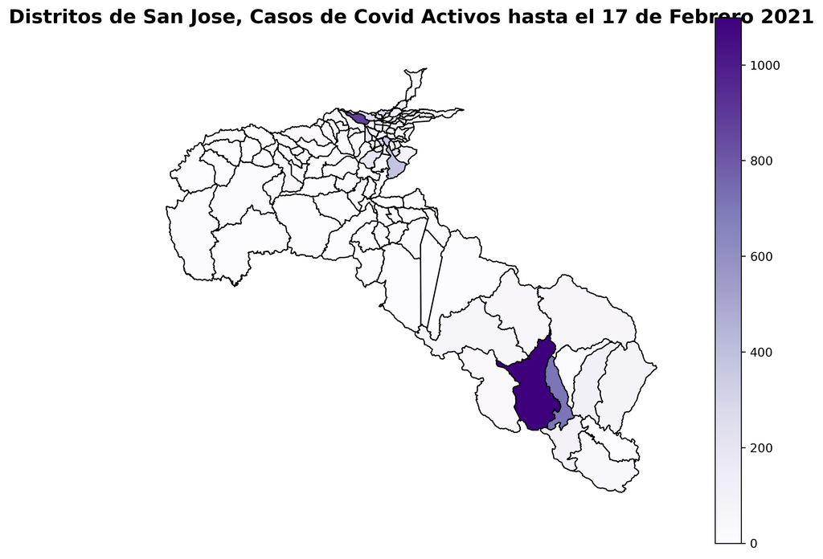

```python
import matplotlib.pyplot as plt

# fig: contenedor
# ax: grafico
fig, ax = plt.subplots(1, 1, figsize=(10, 8), dpi = 300)

ax.set_title("Distritos de San Jose, Casos de Covid Activos hasta el 17 de Febrero 2021",
              fontdict = {"fontsize":16},
              pad = 20,
              weight = "bold")
ax.set_axis_off() # eliminamos axis

df.plot(ax = ax,
        column='activos',
        legend = True,
        cmap = 'Purples',
        edgecolor = 'black')
```

## d) Cree 4 grupos utilizando cuantiles.

```python
df_cuantiles =  df.quantile([.1, .25, .5, .75], axis = 0)
df_cuantiles
```

|  | poblacion | area_k2 | cod_provin | cod_canton | codigo_dta | activos |
| --- | --- | --- | --- | --- | --- | --- |
| 0.10 | 1618.0 | 2.111321 | 1.0 | 102.0 | 10202.6 | 2.0 |
| 0.25 | 3084.0 | 3.400111 | 1.0 | 104.0 | 10404.0 | 6.0 |
| 0.50 | 8647.0 | 14.417349 | 1.0 | 108.0 | 10807.0 | 33.0 |
| 0.75 | 20461.0 | 36.850738 | 1.0 | 116.0 | 11601.0 | 98.0 |

```python
grupos = []

for i in df.activos:
    if i == 0 :
        grupos.append("0")
    elif i > 2 and i <= 5.9:
        grupos.append("Primer Quartil")
    elif i > 6 and i <= 32.9:
        grupos.append("Segundo Quartil")
    elif i > 33 and i <= 97.9:
        grupos.append("Tercer Quartil")
    elif i > 98:
        grupos.append("Cuarto Quartil")
    else:
        grupos.append("Sin Datos")

grupos
```

```
['Tercer Quartil',
 'Segundo Quartil',
 'Tercer Quartil',
 'Cuarto Quartil',
 'Segundo Quartil',
 'Cuarto Quartil',
 'Tercer Quartil',
 'Segundo Quartil',
 'Cuarto Quartil',
 'Tercer Quartil',
 'Tercer Quartil',
 'Tercer Quartil',
 'Sin Datos',
 'Primer Quartil',
 'Sin Datos',
 'Primer Quartil',
 'Sin Datos',
 'Segundo Quartil',
 'Sin Datos',
 'Segundo Quartil',
 '0',
 'Sin Datos',
 'Sin Datos',
 'Sin Datos',
 'Sin Datos',
 'Sin Datos',
 '0',
 'Segundo Quartil',
 'Primer Quartil',
 'Primer Quartil',
 'Segundo Quartil',
 'Segundo Quartil',
 'Sin Datos',
 'Segundo Quartil',
 'Primer Quartil',
 'Segundo Quartil',
 'Sin Datos',
 'Segundo Quartil',
 'Segundo Quartil',
 'Segundo Quartil',
```

[output cut: 68 more lines]

```
 'Cuarto Quartil',
 'Cuarto Quartil',
 'Tercer Quartil',
 'Cuarto Quartil',
 'Tercer Quartil',
 'Segundo Quartil',
 'Sin Datos',
 'Sin Datos',
 'Sin Datos',
 'Sin Datos',
 'Tercer Quartil',
 'Tercer Quartil',
 'Sin Datos',
 'Sin Datos',
 '0']
```

```python
df["grupos"] = pd.Categorical(values = grupos,
categories = ['Sin Datos',"0",'Primer Quartil','Segundo Quartil','Tercer Quartil','Cuarto Quartil'],
ordered = True)
```

## e) Agregue al gráfico un título, subtitulo y fuente, así como las anotaciones que considere necesarias

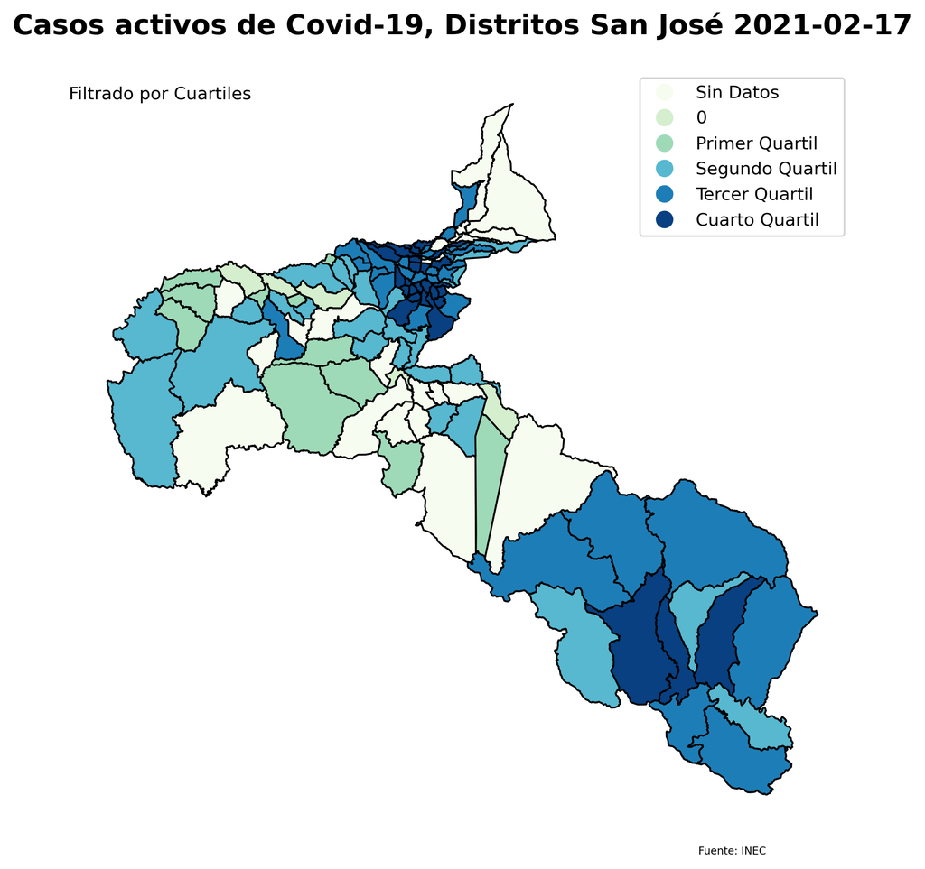

```python
fig, ax = plt.subplots(1, 1, figsize=(10, 8), dpi = 300)

ax.set_title("Casos activos de Covid-19, Distritos San José 2021-02-17",
              fontdict = {"fontsize":16},
              pad = 20,
              weight = "bold")
fig.text(0.2,0.85,"Filtrado por Cuartiles", fontdict={"fontsize":10})
fig.text(0.7,0.1,"Fuente: INEC", fontdict={"fontsize":6})

ax.set_axis_off() # eliminamos axis

df.plot(ax = ax,
        column = 'grupos', # variable a graficar
        legend = True,
        edgecolor = 'black',
        cmap = 'GnBu')
```

# 2. [50 puntos] Utilizando los datos de la tabla `delitoscr.csv` realice lo siguiente:

## a) Utilizando la función `read_csv` de la biblioteca `pandas` lea los datos.

```python
datos = pd.read_csv('../datos/delitoscr.csv', index_col = 0)

datos['Fecha'] = pd.to_datetime(
  datos['Fecha'],
  format="%Y-%m-%d"
)
datos.head()
```

|  | Delito | SubDelito | Fecha | Victima | SubVictima | Edad | Genero | Nacionalidad | Provincia | Canton | Distrito |
| --- | --- | --- | --- | --- | --- | --- | --- | --- | --- | --- | --- |
| 1 | ASALTO | Arma Blanca | 2010-10-17 | PERSONA | Peaton [Persona] | Mayor De Edad | Hombre | Costa Rica | San Jose | Desamparados | Desamparados |
| 2 | ASALTO | Arma Blanca | 2010-06-01 | PERSONA | Peaton [Persona] | Mayor De Edad | Mujer | Costa Rica | San Jose | San Jose | Carmen |
| 3 | ASALTO | Arma Blanca | 2010-10-18 | PERSONA | Peaton [Persona] | Mayor De Edad | Hombre | Nicaragua | San Jose | San Jose | Hospital |
| 4 | ASALTO | Arma Blanca | 2010-07-29 | PERSONA | Peaton [Persona] | Mayor De Edad | Mujer | Costa Rica | Guanacaste | Liberia | Liberia |
| 5 | ASALTO | Arma Blanca | 2010-03-11 | PERSONA | Peaton [Persona] | Mayor De Edad | Hombre | Costa Rica | San Jose | San Jose | Merced |

## b) Seleccione una provincia de su preferencia y realice el conteo de los delitos reportados agrupando los datos por cantón, para esto puede utilizar la función `groupby` del objeto `pandas`

```python
cantones = gp.read_file("../datos/geo_data/cantones/cantones.shp")

cantones_SJO = cantones[cantones['provincia']=='San José']
delitoscr_SJO = datos[datos['Provincia'] == 'San Jose']
delitoscr_SJO.columns = [x.lower() for x in delitoscr_SJO.columns.values]
delitoscr_SJO
```

|  | delito | subdelito | fecha | victima | subvictima | edad | genero | nacionalidad | provincia | canton | distrito |
| --- | --- | --- | --- | --- | --- | --- | --- | --- | --- | --- | --- |
| 1 | ASALTO | Arma Blanca | 2010-10-17 | PERSONA | Peaton [Persona] | Mayor De Edad | Hombre | Costa Rica | San Jose | Desamparados | Desamparados |
| 2 | ASALTO | Arma Blanca | 2010-06-01 | PERSONA | Peaton [Persona] | Mayor De Edad | Mujer | Costa Rica | San Jose | San Jose | Carmen |
| 3 | ASALTO | Arma Blanca | 2010-10-18 | PERSONA | Peaton [Persona] | Mayor De Edad | Hombre | Nicaragua | San Jose | San Jose | Hospital |
| 5 | ASALTO | Arma Blanca | 2010-03-11 | PERSONA | Peaton [Persona] | Mayor De Edad | Hombre | Costa Rica | San Jose | San Jose | Merced |
| 9 | ASALTO | Arma Blanca | 2010-12-13 | PERSONA | Peaton [Persona] | Menor De Edad | Hombre | Costa Rica | San Jose | Perez Zeledon | San Isidro De El General |
| ... | ... | ... | ... | ... | ... | ... | ... | ... | ... | ... | ... |
| 59877 | ASALTO | Otro O Indeterminado | 2015-12-16 | PERSONA | Peaton [Persona] | Desconocido | Mujer | Desconocido | San Jose | San Jose | Pavas |
| 59878 | ASALTO | Otro O Indeterminado | 2015-12-30 | PERSONA | Peaton [Persona] | Mayor De Edad | Mujer | Nicaragua | San Jose | San Jose | Merced |
| 59883 | ASALTO | Uso De Gas | 2015-05-11 | PERSONA | Peaton [Persona] | Mayor De Edad | Mujer | Costa Rica | San Jose | San Jose | Merced |
| 59885 | ASALTO | Uso De Gas | 2015-08-19 | PERSONA | Peaton [Persona] | Adulto Mayor | Hombre | Costa Rica | San Jose | San Jose | Hospital |
| 59888 | ASALTO | Uso De Gas | 2015-10-31 | PERSONA | Peaton [Persona] | Mayor De Edad | Hombre | Costa Rica | San Jose | Aserri | Aserri |

30017 rows × 11 columns

```python
delitos_mes_canton = delitoscr_SJO.groupby(["canton"]).count()["delito"]
delitos_mes_canton.head(20)
```

```
canton
Acosta              19
Alajuelita        1157
Aserri             484
Curridabat        1204
Desamparados      3021
Desconocido        108
Dota                 7
Escazu             759
Goicoechea        1771
Leon Cortes         19
Montes De Oca     2115
Mora                55
Moravia            655
Perez Zeledon     1110
Puriscal            76
San Jose         15035
Santa Ana          393
Tarrazu             46
Tibas             1443
Turrubares           3
Name: delito, dtype: int64
```

```python
cantones_SJO.canton = [arreglar(x) for x in cantones_SJO.canton]
cantones_SJO.canton
```

```
5           Perez Zeledon
9                 Tarrazu
10                   Dota
12     Leon Cortes Castro
13               Puriscal
14                 Aserri
15           Desamparados
16                 Acosta
17             Turrubares
24                   Mora
26             Alajuelita
29             Curridabat
31               San Jose
32                 Escazu
34              Santa Ana
36          Montes De Oca
37             Goicoechea
38                  Tibas
43                Moravia
45    Vazquez De Coronado
Name: canton, dtype: object
```

```python
delitos_mes_canton.index = [arreglar(x) for x in delitos_mes_canton.index]
delitos_mes_canton.head()
```

```
Acosta            19
Alajuelita      1157
Aserri           484
Curridabat      1204
Desamparados    3021
Name: delito, dtype: int64
```

```python
df = cantones_SJO.merge(delitos_mes_canton, left_on = "canton", right_index=True)
df.head(15)
```

|  | provincia | canton | poblacion | area_k2 | geometry | delito |
| --- | --- | --- | --- | --- | --- | --- |
| 5 | San José | Perez Zeledon | 142789.0 | 1901.393446 | POLYGON ((-83.77329 9.59825, -83.77217 9.59826... | 1110 |
| 9 | San José | Tarrazu | 18264.0 | 290.111618 | POLYGON ((-83.98178 9.71802, -83.97882 9.71819... | 46 |
| 10 | San José | Dota | 7846.0 | 405.833655 | POLYGON ((-83.98595 9.73927, -83.98254 9.73711... | 7 |
| 13 | San José | Puriscal | 37345.0 | 554.985169 | POLYGON ((-84.40184 9.90958, -84.40088 9.90939... | 76 |
| 14 | San José | Aserri | 62477.0 | 168.425499 | POLYGON ((-84.08014 9.87557, -84.07916 9.87509... | 484 |
| 15 | San José | Desamparados | 240671.0 | 118.856550 | POLYGON ((-84.07084 9.90794, -84.07184 9.90590... | 3021 |
| 16 | San José | Acosta | 21677.0 | 342.637192 | POLYGON ((-84.16035 9.86151, -84.15553 9.86064... | 19 |
| 17 | San José | Turrubares | 6703.0 | 416.336372 | POLYGON ((-84.42310 9.92265, -84.42128 9.92045... | 3 |
| 24 | San José | Mora | 29821.0 | 163.582368 | POLYGON ((-84.39320 9.93618, -84.38859 9.93600... | 55 |
| 26 | San José | Alajuelita | 91917.0 | 21.351094 | POLYGON ((-84.11848 9.92988, -84.11462 9.92468... | 1157 |
| 29 | San José | Curridabat | 78331.0 | 16.067883 | POLYGON ((-84.01726 9.93809, -84.01454 9.93861... | 1204 |
| 31 | San José | San Jose | 684376.0 | 44.620340 | POLYGON ((-84.17302 9.97182, -84.16864 9.96570... | 15035 |
| 32 | San José | Escazu | 68728.0 | 34.599203 | POLYGON ((-84.18364 9.97217, -84.18258 9.96850... | 759 |
| 34 | San José | Santa Ana | 58946.0 | 61.388698 | POLYGON ((-84.18955 9.97324, -84.18648 9.97240... | 393 |
| 36 | San José | Montes De Oca | 62107.0 | 15.816991 | POLYGON ((-83.99177 9.95259, -83.99094 9.95256... | 2115 |

## c) Utilizando a libreria `folium` cree un mapa interactivo que permita saber el nombre del cantón y cantidad de asaltos reportados.

```python
from IPython.display import display
```

```python
import folium

m = folium.Map(location = [10.41, -84.024578],
            zoom_start = 9.47)
```

```python
choropleth = folium.Choropleth(
 geo_data = df,
 data = df,
 columns = ["canton","delito"],
 key_on = "feature.properties.canton",
 fill_color = 'OrRd',
 highlight = True).add_to(m)


folium.LayerControl().add_to(m)

choropleth.geojson.add_child(
    folium.features.GeoJsonTooltip(['provincia','canton','delito'], labels=False)
).add_to(m)
```

```
<folium.features.GeoJson at 0x7fce4aa88070>
```

```python
display(m)
```

Make this Notebook Trusted to load map: File -> Trust Notebook

[interactive chart not shown]

# 3. [10 puntos] Utilizando la tabla `iris.csv` y la biblioteca `seaborn` realice lo siguiente:

```python
iris = pd.read_csv('../datos/iris.csv',delimiter=';',decimal="." )


print(datos.info(), "\n")
datos.head()
```

[output not shown]

[output not shown]

## a) Diseñe un gráfico de dispersión que permita visualizar el largo del sépalo y largo del pétalo de las flores.

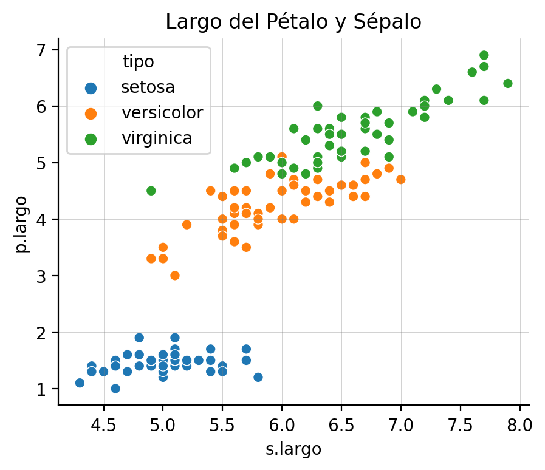

```python
paleta = {
  "virginica": "#1687a7",
  "versicolor": "#eb5e0b",
  "setosa": "#61b15a"
}

fig, ax = plt.subplots(figsize=(5, 4), dpi = 200)

def theme_minimal(ax):
  ax.spines['top'].set_visible(False)
  ax.spines['right'].set_visible(False)
  ax.grid(color='grey', linestyle='-', linewidth=0.25, alpha=0.5)

sb.scatterplot(x = "s.largo",
              y = "p.largo",
              hue = "tipo",
              data = iris,
              ax = ax)
ax.set_title("Largo del Pétalo y Sépalo")
theme_minimal(ax)
```

## b) Replique el gráfico anterior utilizando la biblioteca `plotnine`.

```python
from plotnine import *
from mizani.breaks import date_breaks
from mizani.formatters import date_format
```

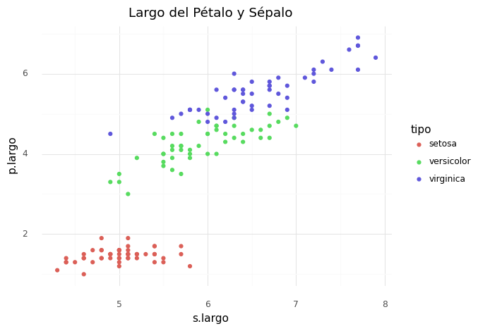

```python
comma = lambda x: [format(int(valor), ',') for valor in x]

(ggplot(iris, aes(x='s.largo', y='p.largo', color = "tipo"))
  +  geom_point()
 + labs(title = "Largo del Pétalo y Sépalo")
 + theme_minimal()
)
```